# Reproducible Research: Peer Assessment 1

## Loading and preprocessing the data

```r
if (!file.exists("activity.csv")){
        unzip("activity.zip")
}
activity <- read.csv(file = "activity.csv", colClasses=c(NA,"Date",NA), stringsAsFactors=T, header = TRUE)
```

## What is mean total number of steps taken per day?

```r
library(plyr)

activityPerDay <- ddply(.data = activity, .(date), summarize, stepsPerDay=sum(steps,na.rm = TRUE))
```

### Make a histogram of the total number of steps taken each day

I researched the difference between a histogram and a barplot, then based my graphs after reading the following pages:

- [Histograms vs Bar Graphs](http://www.shodor.org/interactivate/discussions/HistogramsVsBarGraph/)
- Plotting distributions (ggplot2)
- [GGPlot Histogram](http://docs.ggplot2.org/current/geom_histogram.html)

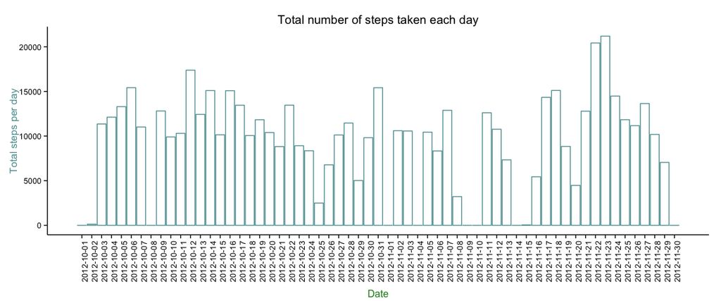

```r
library(ggplot2)
g <- ggplot(activityPerDay)
g <- g + geom_histogram(colour = "cadetblue", fill = "white",binwidth=.1, position="identity", aes(x=date, y=stepsPerDay), stat="identity")
g <- g + ggtitle("Total number of steps taken each day") + xlab("Date") + ylab("Total steps per day")
g <- g + scale_x_date(breaks = activityPerDay$date)
g <- g + theme_classic() + theme(axis.text.x = element_text(angle=90, hjust=1))

g <- g +  theme(axis.title.x = element_text(color="forestgreen", vjust=-0.35),
      axis.title.y = element_text(color="cadetblue" , vjust=0.35) )


# save it for later
histogramStepsPerDay <- g

# show
g
```

### Calculate and report the mean and median of the total number of steps taken per day

Following is a table displaying the total number of steps taken for each day, along with its mean and median.

*Note*: The HTML table may not show properly when reading the `.md` file in GitHub, please refer to the accompanying `.html` version to see properly.

```r
library(plyr)

activityPerDay <- ddply(.data = activity, .(date), summarize, stepsPerDay=sum(steps,na.rm = TRUE), mean= ifelse(is.na(mean(steps, na.rm = T)),0,round(mean(steps, na.rm=T),2)) , median= ifelse(is.na(median(steps, na.rm = T)),0,median(steps, na.rm=T)) )

#kable(activityPerDay, col.names = c("Date", "Total steps per day", "Mean", "Median"), caption="Mean and median of the total number of steps taken per day")
activityPerDay
```

```
##          date stepsPerDay  mean median
## 1  2012-10-01           0  0.00      0
## 2  2012-10-02         126  0.44      0
## 3  2012-10-03       11352 39.42      0
## 4  2012-10-04       12116 42.07      0
## 5  2012-10-05       13294 46.16      0
## 6  2012-10-06       15420 53.54      0
## 7  2012-10-07       11015 38.25      0
## 8  2012-10-08           0  0.00      0
## 9  2012-10-09       12811 44.48      0
## 10 2012-10-10        9900 34.38      0
## 11 2012-10-11       10304 35.78      0
## 12 2012-10-12       17382 60.35      0
## 13 2012-10-13       12426 43.15      0
## 14 2012-10-14       15098 52.42      0
```

[output cut: 47 more lines]

## What is the average daily activity pattern?

1. Make a time series plot (i.e. type = “l”) of the 5-minute interval (x-axis) and the average number of steps taken, averaged across all days (y-axis)

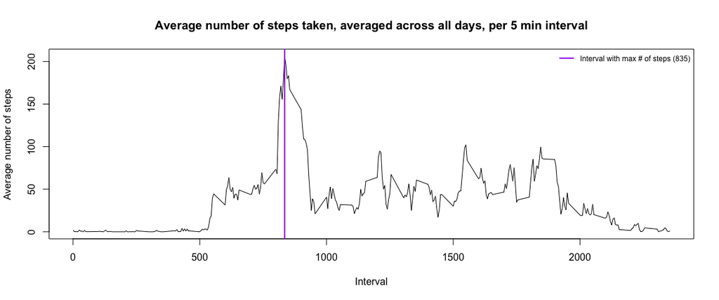

```r
averageByInterval <- ddply(.data = activity, .(interval), summarize, mean=mean(steps, na.rm=T ))

highestInterval <- averageByInterval[averageByInterval$mean==max(averageByInterval$mean),"interval"]
highestIntervalLabel <- paste0("Interval with max # of steps (",highestInterval,")")

with(averageByInterval,{
        plot(mean ~ interval, type="l", ylab = "Average number of steps", xlab="Interval")
        abline(v=highestInterval, col="purple", lwd=2)
        title(main="Average number of steps taken, averaged across all days, per 5 min interval")
        legend(x="topright",
                cex=0.75, c(highestIntervalLabel),
                col=c("purple"), lty=c(1), bty="n", lwd = c(2))

})
```

2. Which 5-minute interval, on average across all the days in the dataset, contains the maximum number of steps?

```r
averageByInterval[averageByInterval$mean==max(averageByInterval$mean),]
```

```
##     interval     mean
## 104      835 206.1698
```

## Imputing missing values

1. Calculate and report the total number of missing values in the dataset (i.e. the total number of rows with NAs)

```r
summary(activity$steps)["NA's"]
```

```
## NA's
## 2304
```

2. Devise a strategy for filling in all of the missing values in the dataset. The strategy does not need to be sophisticated. For example, you could use the mean/median for that day, or the mean for that 5-minute interval, etc.

Given that I calculated the mean values in `activityPerDay` above, I will use those mean values to replace the original `NA`s by performing the equivalent of a relational *left join*, and then projecting the right values, then renaming the resulting columns to match the original ones.

3. Create a new dataset that is equal to the original dataset but with the missing data filled in.

```r
merged <- merge(activity, activityPerDay, by="date", all.x=T)
fixed0 <- merged[,c("date","interval","mean","steps")]
fixed <- ddply(fixed0, .(date, interval), function(r){ c(ifelse(is.na(r$steps),r$mean,r$steps))})
colnames(fixed) <- c("date","interval","steps")
```

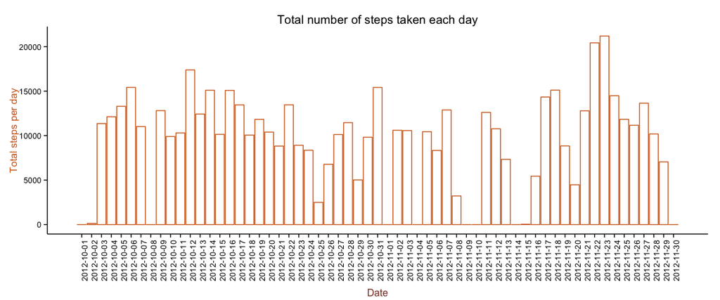

```r
library(ggplot2)
activityPerDayFixed <- ddply(.data = activity, .(date), summarize, stepsPerDay=sum(steps,na.rm = TRUE))

g <- ggplot(activityPerDayFixed)
g <- g + geom_histogram(colour = "chocolate", fill = "white",binwidth=.1, position="identity", aes(x=date, y=stepsPerDay), stat="identity")
g <- g + ggtitle("Total number of steps taken each day") + xlab("Date") + ylab("Total steps per day")
g <- g + scale_x_date(breaks = activityPerDayFixed$date)
g <- g + theme_classic() + theme(axis.text.x = element_text(angle=90, hjust=1))

g <- g +  theme(axis.title.x = element_text(color="coral4", vjust=-0.35),
      axis.title.y = element_text(color="chocolate" , vjust=0.35) )


histogramStepsPerDayFixed <- g

g
```

4. 1. Do these values differ from the estimates from the first part of the assignment?

Visual inspection of both histograms suggests they *do not differ*.

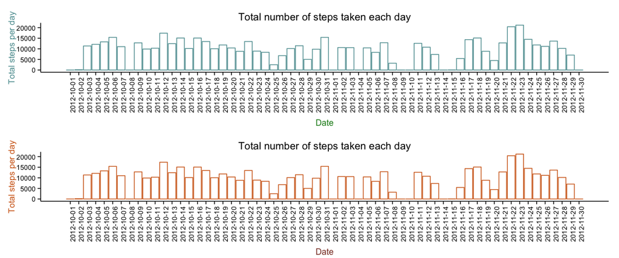

```r
# based on http://zevross.com/blog/2014/08/04/beautiful-plotting-in-r-a-ggplot2-cheatsheet-3/#put-two-potentially-unrelated-plots-side-by-side-pushviewport
library(grid)
pushViewport(viewport(layout = grid.layout(2, 1)))
print(histogramStepsPerDay, vp = viewport(layout.pos.row = 1, layout.pos.col = 1))
print(histogramStepsPerDayFixed, vp = viewport(layout.pos.row = 2, layout.pos.col = 1))
```

## Are there differences in activity patterns between weekdays and weekends?

1. Create a new factor variable in the dataset with two levels – “weekday” and “weekend” indicating whether a given date is a weekday or weekend day.

```r
library(stringr)

activity <- transform(activity, typeOfDay=ifelse(str_detect(weekdays(date),"Sunday|Saturday"),"weekend","weekday"))

# show random sample to demonstrate it worked
set.seed(10)
activity[sample(nrow(activity),10),]
```

```
##       steps       date interval typeOfDay
## 8916      0 2012-10-31     2255   weekday
## 5390      0 2012-10-19     1705   weekday
## 7500      0 2012-10-27       55   weekend
## 12175     0 2012-11-12      630   weekday
## 1496      0 2012-10-06      435   weekend
## 3960     43 2012-10-14     1755   weekend
## 4822      0 2012-10-17     1745   weekday
## 4782      0 2012-10-17     1425   weekday
## 10814   147 2012-11-07     1305   weekday
## 7545      0 2012-10-27      440   weekend
```

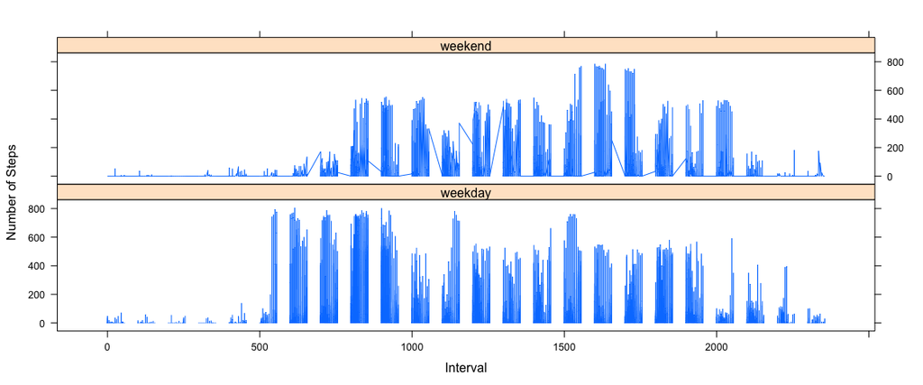

```r
library(plyr)
library(lattice)

averageByIntervalWeekdays <- ddply(.data = activity, .(interval, date), summarize, mean=mean(steps, na.rm=T ), typeOfDay=typeOfDay)

xyplot(mean ~ interval | typeOfDay, averageByIntervalWeekdays, type="l", xlab = "Interval", ylab="Number of Steps", layout = c(1,2))
```